# Reliability and CFA Multi-levels analysis - Model_final

## Descriptive statistics - Check minimum/maximum values per item, and screen for missing values

```r
cat("\n\n==========================================\n
    ==========================================\n
    ==========================================\n")
cat("\n\n BEFORE ITEM REDUCTION\n\n")
```

```
##
##
##  BEFORE ITEM REDUCTION
```

```r
cat("==========================================\n
    ==========================================\n
    ==========================================\n\n")
describe(data)
```

```
##                 vars    n mean   sd median trimmed  mad min max range  skew
## answer             1 1752 1.64 1.42      2    1.87 1.48  -3   3     6 -1.20
## clearData          2 1754 0.80 1.92      1    0.95 2.97  -3   3     6 -0.54
## clearRepresent     3 1756 0.93 1.82      2    1.09 1.48  -3   3     6 -0.65
## complex            4 1751 0.86 1.91      2    1.01 1.48  -3   3     6 -0.55
## confid             5 1754 1.73 1.49      2    2.00 1.48  -3   3     6 -1.41
## confus             6 1754 0.73 2.00      2    0.88 1.48  -3   3     6 -0.46
## crowd              7 1756 0.57 2.02      1    0.71 2.97  -3   3     6 -0.43
## deciph             8 1754 0.77 1.90      1    0.89 2.97  -3   3     6 -0.49
## distinguish        9 1747 1.06 1.80      2    1.26 1.48  -3   3     6 -0.82
## distract          10 1752 0.65 1.92      1    0.76 2.97  -3   3     6 -0.40
## effect            11 1753 1.08 1.75      2    1.28 1.48  -3   3     6 -0.80
## find              12 1755 1.04 1.71      2    1.22 1.48  -3   3     6 -0.77
## identifi          13 1755 1.21 1.67      2    1.41 1.48  -3   3     6 -0.85
## inform            14 1756 1.06 1.75      2    1.25 1.48  -3   3     6 -0.74
## lost              15 1755 0.90 1.89      2    1.06 1.48  -3   3     6 -0.54
## meanElem          16 1755 1.48 1.55      2    1.72 1.48  -3   3     6 -1.17
## meanOveral        17 1754 1.86 1.33      2    2.11 1.48  -3   3     6 -1.49
## messi             18 1755 0.51 2.01      1    0.62 2.97  -3   3     6 -0.32
## obvious           19 1751 1.47 1.67      2    1.73 1.48  -3   3     6 -1.09
## organiz           20 1752 0.78 1.86      1    0.93 1.48  -3   3     6 -0.54
## read              21 1749 1.05 1.84      2    1.24 1.48  -3   3     6 -0.72
## readabl           22 1752 1.29 1.66      2    1.51 1.48  -3   3     6 -0.96
## represent         23 1752 1.47 1.56      2    1.71 1.48  -3   3     6 -1.12
## see               24 1741 0.88 1.74      1    1.03 1.48  -3   3     6 -0.66
## simpl             25 1751 0.81 1.95      2    0.97 1.48  -3   3     6 -0.54
## understandEasi    26 1755 1.29 1.73      2    1.51 1.48  -3   3     6 -0.89
## understandQuick   27 1752 1.07 1.88      2    1.27 1.48  -3   3     6 -0.75
## valu              28 1739 1.29 1.60      2    1.52 1.48  -3   3     6 -1.10
## visibl            29 1734 0.93 1.70      1    1.09 1.48  -3   3     6 -0.75
##                 kurtosis   se
## answer              0.90 0.03
## clearData          -1.04 0.05
## clearRepresent     -0.83 0.04
## complex            -1.07 0.05
## confid              1.38 0.04
## confus             -1.24 0.05
## crowd              -1.20 0.05
## deciph             -1.10 0.05
## distinguish        -0.50 0.04
## distract           -1.18 0.05
## effect             -0.46 0.04
## find               -0.47 0.04
## identifi           -0.31 0.04
## inform             -0.60 0.04
## lost               -1.04 0.05
## meanElem            0.55 0.04
## meanOveral          1.96 0.03
## messi              -1.31 0.05
## obvious             0.19 0.04
## organiz            -0.92 0.04
## read               -0.75 0.04
## readabl            -0.07 0.04
## represent           0.44 0.04
## see                -0.64 0.04
## simpl              -1.07 0.05
## understandEasi     -0.40 0.04
## understandQuick    -0.74 0.04
## valu                0.49 0.04
## visibl             -0.46 0.04
```

```r
response.frequencies(data)
```

```
##                          -3         -2         -1          0          1
## answer          0.010844749 0.03538813 0.06506849 0.05650685 0.18093607
## clearData       0.061003421 0.11060433 0.14025086 0.05473204 0.13740023
## clearRepresent  0.043280182 0.10079727 0.13097950 0.05410023 0.16173121
## complex         0.047401485 0.11993147 0.13992005 0.05368361 0.12450029
## confid          0.018814139 0.03876853 0.05359179 0.04846066 0.13911060
## confus          0.068415051 0.12485747 0.15507412 0.04960091 0.09007982
## crowd           0.097949886 0.11958998 0.12414579 0.07517084 0.12699317
## deciph          0.050171038 0.12770810 0.13397948 0.07297605 0.12542759
## distinguish     0.048082427 0.08700630 0.10131654 0.04979966 0.17515741
## distract        0.062214612 0.12271689 0.15410959 0.07876712 0.11815068
## effect          0.040501997 0.08043354 0.10496292 0.06674273 0.16942384
## find            0.035897436 0.07920228 0.11452991 0.06438746 0.19202279
## identifi        0.027920228 0.06438746 0.11168091 0.07065527 0.15897436
## inform          0.034168565 0.08428246 0.12186788 0.05865604 0.17198178
## lost            0.046153846 0.09572650 0.16182336 0.06609687 0.10997151
## meanElem        0.020512821 0.05242165 0.07635328 0.04957265 0.15954416
## meanOveral      0.009692132 0.02394527 0.05017104 0.04732041 0.13169897
## messi           0.084900285 0.13447293 0.15783476 0.06096866 0.12079772
## obvious         0.028555111 0.05768132 0.08338093 0.05025700 0.14905768
## organiz         0.058789954 0.09988584 0.12728311 0.08961187 0.15696347
## read            0.042881647 0.09262436 0.12064037 0.06117782 0.13493425
## readabl         0.029680365 0.06164384 0.09417808 0.06792237 0.15810502
## represent       0.020547945 0.05251142 0.07534247 0.05650685 0.16837900
## see             0.045376221 0.08845491 0.11200460 0.09362435 0.18897186
## simpl           0.062821245 0.11536265 0.13420902 0.05596802 0.12564249
## understandEasi  0.022792023 0.08831909 0.09686610 0.05299145 0.14415954
## understandQuick 0.048515982 0.10273973 0.10331050 0.05251142 0.13812785
## valu            0.036227717 0.05750431 0.05807936 0.07015526 0.20874066
## visibl          0.043829296 0.07958478 0.10438293 0.09169550 0.19838524
##                         2         3        miss
## answer          0.3304795 0.3207763 0.003412969
## clearData       0.2839225 0.2120867 0.002275313
## clearRepresent  0.2984055 0.2107062 0.001137656
## complex         0.2872644 0.2272987 0.003981797
## confid          0.3283922 0.3728620 0.002275313
## confus          0.2839225 0.2280502 0.002275313
## crowd           0.2642369 0.1919134 0.001137656
## deciph          0.2890536 0.2006842 0.002275313
## distinguish     0.3091013 0.2295363 0.006257110
## distract        0.2756849 0.1883562 0.003412969
## effect          0.3126070 0.2253280 0.002844141
## find            0.3133903 0.2005698 0.001706485
## identifi        0.3219373 0.2444444 0.001706485
## inform          0.3029613 0.2260820 0.001137656
## lost            0.2740741 0.2461538 0.001706485
## meanElem        0.3589744 0.2826211 0.001706485
## meanOveral      0.3586089 0.3785633 0.002275313
## messi           0.2484330 0.1925926 0.001706485
## obvious         0.2895488 0.3415191 0.003981797
## organiz         0.2716895 0.1957763 0.003412969
## read            0.2904517 0.2572899 0.005119454
## readabl         0.3287671 0.2597032 0.003412969
## represent       0.3316210 0.2950913 0.003412969
## see             0.3026996 0.1688685 0.009670080
## simpl           0.2764135 0.2295831 0.003981797
## understandEasi  0.2974359 0.2974359 0.001706485
## understandQuick 0.2813927 0.2734018 0.003412969
## valu            0.3467510 0.2225417 0.010807736
## visibl          0.3235294 0.1585928 0.013651877
```

```r
nb_obs <- nrow(data)
cat("\n Sample size:")
```

```
##
##  Sample size:
```

```r
print(nb_obs)
```

```
## [1] 1758
```

```r
#corr Matrix with all possible items
data_all_factors <- data %>% select(all_of(full_columns_to_keep))
corrM <- make_corrM(data_all_factors, nb_fa = 4)

num_items <- ncol(data_all_factors)
## as csv
write.csv(corrM,file="generatedData-CFA/correlations/factors-all_items-corr.csv")
# as pdf
this_file <- "generatedPlots-CFA/correlations/factors-all_items-corr.pdf"
pdf(this_file, height=15, width=15)
plot <- corrplot(corrM,
        # type = 'lower', #only lower half
        tl.srt = 30, #rotate text labels
        method="color",
        col = COL2('RdYlBu'),
        order="original",
        addrect = 4,
        tl.col="black", tl.cex = 1.3, # Text label color and size
        addCoef.col = "white", number.cex = 1, # Add coefficient of correlation and size
        )
dev.off()
```

# Factor by factor (full, non-reduced) alpha reliability and item-total correlations

```r
list_alpha_dfs <- list()

for (factor in names(full_Readability_factors)) {
  cat(paste("\n ======================\n Individual full factor reliability for", factor, "\n (omega and alpha) \n"))
  this_factor_columns <- unlist(full_Readability_factors[[factor]])
  factor_data <- data %>% select(all_of(this_factor_columns))

  this_filename = paste(factor, "-corr", sep = "")
  corrM_to_file(factor_data, file = this_filename, this_factor_columns)

  # factor-wise reliability
  # omega
  nb_obs <- nrow(factor_data)
  corrM <- make_corrM(factor_data, nb_fa = 1)
  om <- omega(corrM, n.obs = nb_obs, 1)
  summary(om)

  #alpha
  alpha_values <- psych::alpha(factor_data)

  cat("Alpha raw:")
  print(alpha_values$total$raw_alpha)
  print(alpha_values$total)

  # output df
  factor_alpha_df <- alpha_values$total
  factor_alpha_df$omega_tot <- om$omega.tot
  write.csv(factor_alpha_df,file=paste("generatedData-CFA/reliability/to aggregate/",factor,"-full_data-reliability.csv", sep = ""))

  # factor-wise reliability for each stimulus
  for (letter in stimuli_letters){
    the_data <- filter(grp_data, stimulus == letter)
    stimulus_factor_data <- the_data %>% select(all_of(this_factor_columns))

    # omega
    nb_obs <- nrow(stimulus_factor_data)
    corrM <- make_corrM(stimulus_factor_data, nb_fa = 1)
    om <- omega(corrM, n.obs = nb_obs, 1)

    # alpha
    alpha_values <- psych::alpha(stimulus_factor_data)

    # output df
    factor_stimulus_alpha_df <- alpha_values$total
    factor_stimulus_alpha_df$omega_tot <- om$omega.tot
  write.csv(factor_stimulus_alpha_df,file=paste("generatedData-CFA/reliability/to aggregate/",factor,"-",letter,"-full_data-reliability.csv", sep =""))
  }

  cat("Alpha items:")
  print(alpha_values$alpha.drop)

  # Extract the row names
  row_names <- gsub(paste(factor, "\\."), "", rownames(alpha_values$alpha.drop))

  # Modify the row names in the data frame and add the "Factor" column
  alpha_values$alpha.drop <- cbind(Factor = factor, alpha_values$alpha.drop)
  rownames(alpha_values$alpha.drop) <- row_names

  # Add the data frame to the list
  list_alpha_dfs[[factor]] <- alpha_values$alpha.drop
}
```

```
##
##  ======================
##  Individual full factor reliability for understand
##  (omega and alpha)
```

[output not shown]

[output cut: 18 more lines]

[output not shown]

```
## Omega_h for 1 factor is not meaningful, just omega_t
```

```
## Omega
## omega(m = corrM, nfactors = 1, n.obs = nb_obs)
## Alpha:                 0.95
## G.6:                   0.95
## Omega Hierarchical:    0.95
## Omega H asymptotic:    1
## Omega Total            0.95
##
## With eigenvalues of:
##   g F1*
## 5.2 0.0
## The degrees of freedom for the model is 14  and the fit was  0.07
## The number of observations was  1758  with Chi Square =  130.27  with prob <  0
##
## The root mean square of the residuals is  0.01
## The df corrected root mean square of the residuals is  0.02
##
## RMSEA and the  0.9 confidence intervals are  0.069 0.058 0.08
## BIC =  25.66Explained Common Variance of the general factor =  1
##
##  Total, General and Subset omega for each subset
##                                                  g  F1*
## Omega total for total scores and subscales    0.95 0.95
## Omega general for total scores and subscales  0.95 0.95
## Omega group for total scores and subscales    0.00 0.00
## Alpha raw:[1] 0.9501802
##  raw_alpha std.alpha   G6(smc) average_r      S/N         ase     mean       sd
##  0.9501802 0.9512568 0.9460019 0.7360054 19.51569 0.001730365 1.478322 1.414508
##   median_r
##  0.7306941
```

```
## Omega_h for 1 factor is not meaningful, just omega_t
```

```
## Omega_h for 1 factor is not meaningful, just omega_t
```

```
## Omega_h for 1 factor is not meaningful, just omega_t
```

```
## Omega_h for 1 factor is not meaningful, just omega_t
```

```
## Omega_h for 1 factor is not meaningful, just omega_t
```

```
## Omega_h for 1 factor is not meaningful, just omega_t
```

```
## Alpha items:                raw_alpha std.alpha   G6(smc) average_r       S/N    alpha se
## obvious         0.9036402 0.9045278 0.8917419 0.6122593  9.474259 0.008571868
## meanOveral      0.9115247 0.9124381 0.8993726 0.6346030 10.420494 0.007976077
## confid          0.9014704 0.9022659 0.8898407 0.6060885  9.231848 0.008767095
## represent       0.9004656 0.9014458 0.8893309 0.6038742  9.146702 0.008877159
## understandEasi  0.8980134 0.8993119 0.8845041 0.5981692  8.931657 0.009101661
## understandQuick 0.9051963 0.9053326 0.8911964 0.6144777  9.563301 0.008500215
## meanElem        0.9070469 0.9081309 0.8963039 0.6222864  9.885051 0.008285376
##                       var.r     med.r
## obvious         0.003786342 0.6047383
## meanOveral      0.001381374 0.6231998
## confid          0.003302845 0.6000743
## represent       0.002877610 0.6047383
## understandEasi  0.002170548 0.6000743
## understandQuick 0.002037870 0.6108169
## meanElem        0.002898754 0.6175894
##
##  ======================
##  Individual full factor reliability for layout
##  (omega and alpha)
```

[output not shown]

```
## Omega_h for 1 factor is not meaningful, just omega_t
```

```
## Omega
## omega(m = corrM, nfactors = 1, n.obs = nb_obs)
## Alpha:                 0.91
## G.6:                   0.89
## Omega Hierarchical:    0.91
## Omega H asymptotic:    1
## Omega Total            0.91
##
## With eigenvalues of:
##   g F1*
## 2.9 0.0
## The degrees of freedom for the model is 2  and the fit was  0.02
## The number of observations was  1758  with Chi Square =  39.63  with prob <  0
##
## The root mean square of the residuals is  0.02
## The df corrected root mean square of the residuals is  NA
##
## RMSEA and the  0.9 confidence intervals are  0.103 0.077 0.133
## BIC =  24.68Explained Common Variance of the general factor =  1
##
##  Total, General and Subset omega for each subset
##                                                  g  F1*
## Omega total for total scores and subscales    0.91 0.91
## Omega general for total scores and subscales  0.91 0.91
## Omega group for total scores and subscales    0.00 0.00
## Alpha raw:[1] 0.9073256
##  raw_alpha std.alpha   G6(smc) average_r      S/N         ase      mean
##  0.9073256 0.9074157 0.8860662 0.7101652 9.800967 0.003606033 0.6302143
##        sd  median_r
##  1.727365 0.6987898
```

```
## Omega_h for 1 factor is not meaningful, just omega_t
```

```
## Omega_h for 1 factor is not meaningful, just omega_t
```

```
## Omega_h for 1 factor is not meaningful, just omega_t
```

```
## Omega_h for 1 factor is not meaningful, just omega_t
```

```
## Omega_h for 1 factor is not meaningful, just omega_t
```

```
## Omega_h for 1 factor is not meaningful, just omega_t
```

```
## Alpha items:         raw_alpha std.alpha   G6(smc) average_r      S/N   alpha se
## crowd    0.7925868 0.7986202 0.7486212 0.5693207 3.965740 0.02148939
## messi    0.7395585 0.7463597 0.6662663 0.4951697 2.942591 0.02622821
## distract 0.8540855 0.8596416 0.8212158 0.6712192 6.124619 0.01489452
## organiz  0.8009875 0.8098617 0.7641854 0.5867387 4.259329 0.02073519
##                var.r     med.r
## crowd    0.017546698 0.5428042
## messi    0.003120819 0.4750900
## distract 0.009777724 0.7130372
## organiz  0.019300899 0.5428042
##
##  ======================
##  Individual full factor reliability for dataRead
##  (omega and alpha)
```

[output not shown]

```
## Omega_h for 1 factor is not meaningful, just omega_t
```

```
## Omega
## omega(m = corrM, nfactors = 1, n.obs = nb_obs)
## Alpha:                 0.92
## G.6:                   0.91
## Omega Hierarchical:    0.93
## Omega H asymptotic:    1
## Omega Total            0.93
##
## With eigenvalues of:
##   g F1*
## 3.6 0.0
## The degrees of freedom for the model is 5  and the fit was  0.02
## The number of observations was  1758  with Chi Square =  35.29  with prob <  0
##
## The root mean square of the residuals is  0.01
## The df corrected root mean square of the residuals is  0.04
##
## RMSEA and the  0.9 confidence intervals are  0.059 0.041 0.078
## BIC =  -2.07Explained Common Variance of the general factor =  1
##
##  Total, General and Subset omega for each subset
##                                                  g  F1*
## Omega total for total scores and subscales    0.93 0.93
## Omega general for total scores and subscales  0.93 0.93
## Omega group for total scores and subscales    0.00 0.00
## Alpha raw:[1] 0.923072
##  raw_alpha std.alpha   G6(smc) average_r      S/N        ase     mean       sd
##   0.923072 0.9222918 0.9119515 0.7035922 11.86865 0.00289668 1.176432 1.470998
##   median_r
##  0.7585266
```

```
## Omega_h for 1 factor is not meaningful, just omega_t
```

```
## Omega_h for 1 factor is not meaningful, just omega_t
```

```
## Omega_h for 1 factor is not meaningful, just omega_t
```

```
## Omega_h for 1 factor is not meaningful, just omega_t
```

```
## Omega_h for 1 factor is not meaningful, just omega_t
```

```
## Omega_h for 1 factor is not meaningful, just omega_t
```

```
## Alpha items:         raw_alpha std.alpha   G6(smc) average_r       S/N    alpha se
## find     0.8733922 0.8704255 0.8504544 0.6267810  6.717568 0.011279675
## identifi 0.8638887 0.8618789 0.8377023 0.6093758  6.240022 0.012130742
## valu     0.9183362 0.9184604 0.8954475 0.7379451 11.263977 0.007796958
## inform   0.8671971 0.8653765 0.8413624 0.6164219  6.428123 0.011863437
## readabl  0.8733969 0.8700522 0.8506215 0.6260074  6.695400 0.011184061
##                var.r     med.r
## find     0.018933373 0.6265808
## identifi 0.014913957 0.6037885
## valu     0.001011051 0.7404136
## inform   0.014548995 0.6037885
## readabl  0.021125588 0.6235235
##
##  ======================
##  Individual full factor reliability for dataFeat
##  (omega and alpha)
```

[output not shown]

```
## Omega_h for 1 factor is not meaningful, just omega_t
```

```
## Omega
## omega(m = corrM, nfactors = 1, n.obs = nb_obs)
## Alpha:                 0.88
## G.6:                   0.78
## Omega Hierarchical:    0.88
## Omega H asymptotic:    1
## Omega Total            0.88
##
## With eigenvalues of:
##   g F1*
## 1.6 0.0
## The degrees of freedom for the model is -1  and the fit was  0
## The number of observations was  1758  with Chi Square =  0  with prob <  NA
##
## The root mean square of the residuals is  0
## The df corrected root mean square of the residuals is  NA
## Explained Common Variance of the general factor =  1
##
##  Total, General and Subset omega for each subset
##                                                  g  F1*
## Omega total for total scores and subscales    0.88 0.88
## Omega general for total scores and subscales  0.88 0.88
## Omega group for total scores and subscales    0.00 0.00
## Alpha raw:[1] 0.8786794
##  raw_alpha std.alpha   G6(smc) average_r      S/N         ase      mean
##  0.8786794 0.8788328 0.7838552 0.7838552 7.253056 0.005782353 0.8971347
##        sd  median_r
##  1.624389 0.7838552
```

```
## Omega_h for 1 factor is not meaningful, just omega_t
```

```
## Omega_h for 1 factor is not meaningful, just omega_t
```

```
## Omega_h for 1 factor is not meaningful, just omega_t
```

```
## Omega_h for 1 factor is not meaningful, just omega_t
```

```
## Omega_h for 1 factor is not meaningful, just omega_t
```

```
## Omega_h for 1 factor is not meaningful, just omega_t
```

```
## Alpha items:       raw_alpha std.alpha   G6(smc) average_r      S/N alpha se var.r
## visibl 0.6548062 0.6986096 0.4880553 0.6986096 2.317955       NA     0
## see    0.7453431 0.6986096 0.4880553 0.6986096 2.317955       NA     0
##            med.r
## visibl 0.6986096
## see    0.6986096
```

```r
# Combine all item information dataframes into one table and export it
combined_df <- do.call(rbind, list_alpha_dfs)
write.csv(combined_df,file=("generatedData-CFA/items_scale_reliability_per_factor.csv"))


# Print the combined data frame
print(combined_df)
```

```
##                                Factor raw_alpha std.alpha   G6(smc) average_r
## understand.obvious         understand 0.9036402 0.9045278 0.8917419 0.6122593
## understand.meanOveral      understand 0.9115247 0.9124381 0.8993726 0.6346030
## understand.confid          understand 0.9014704 0.9022659 0.8898407 0.6060885
## understand.represent       understand 0.9004656 0.9014458 0.8893309 0.6038742
## understand.understandEasi  understand 0.8980134 0.8993119 0.8845041 0.5981692
## understand.understandQuick understand 0.9051963 0.9053326 0.8911964 0.6144777
## understand.meanElem        understand 0.9070469 0.9081309 0.8963039 0.6222864
## layout.crowd                   layout 0.7925868 0.7986202 0.7486212 0.5693207
## layout.messi                   layout 0.7395585 0.7463597 0.6662663 0.4951697
## layout.distract                layout 0.8540855 0.8596416 0.8212158 0.6712192
## layout.organiz                 layout 0.8009875 0.8098617 0.7641854 0.5867387
## dataRead.find                dataRead 0.8733922 0.8704255 0.8504544 0.6267810
## dataRead.identifi            dataRead 0.8638887 0.8618789 0.8377023 0.6093758
## dataRead.valu                dataRead 0.9183362 0.9184604 0.8954475 0.7379451
## dataRead.inform              dataRead 0.8671971 0.8653765 0.8413624 0.6164219
## dataRead.readabl             dataRead 0.8733969 0.8700522 0.8506215 0.6260074
## dataFeat.visibl              dataFeat 0.6548062 0.6986096 0.4880553 0.6986096
## dataFeat.see                 dataFeat 0.7453431 0.6986096 0.4880553 0.6986096
##                                  S/N    alpha se       var.r     med.r
## understand.obvious          9.474259 0.008571868 0.003786342 0.6047383
## understand.meanOveral      10.420494 0.007976077 0.001381374 0.6231998
## understand.confid           9.231848 0.008767095 0.003302845 0.6000743
## understand.represent        9.146702 0.008877159 0.002877610 0.6047383
## understand.understandEasi   8.931657 0.009101661 0.002170548 0.6000743
## understand.understandQuick  9.563301 0.008500215 0.002037870 0.6108169
## understand.meanElem         9.885051 0.008285376 0.002898754 0.6175894
## layout.crowd                3.965740 0.021489387 0.017546698 0.5428042
## layout.messi                2.942591 0.026228211 0.003120819 0.4750900
## layout.distract             6.124619 0.014894521 0.009777724 0.7130372
## layout.organiz              4.259329 0.020735193 0.019300899 0.5428042
## dataRead.find               6.717568 0.011279675 0.018933373 0.6265808
## dataRead.identifi           6.240022 0.012130742 0.014913957 0.6037885
## dataRead.valu              11.263977 0.007796958 0.001011051 0.7404136
## dataRead.inform             6.428123 0.011863437 0.014548995 0.6037885
## dataRead.readabl            6.695400 0.011184061 0.021125588 0.6235235
## dataFeat.visibl             2.317955          NA 0.000000000 0.6986096
## dataFeat.see                2.317955          NA 0.000000000 0.6986096
```

# Omega check on all data

```r
cat("Omega on aggregated data for 4 factors")
```

```
## Omega on aggregated data for 4 factors
```

```r
corrM <- make_corrM(data_all_factors, nb_fa = 4)
om <- omega(corrM, fm="pa", rotate = "Promax", nfactors=4)
```

[figure not shown]

```r
# corrFiml <- corFiml(data)
# omegaFromSem(this_fit,m=corrFiml,flip=TRUE,plot=TRUE)
```

```r
## Create the model from full_Readability_factors
# Apply the function to each element of the list
full_formatted_strings <- sapply(names(full_Readability_factors), function(factor_name) {
  factor_to_string(factor_name, full_Readability_factors[[factor_name]])
})

# Combine the strings into a single string
full_model_string <- paste(full_formatted_strings, collapse = '\n')

# Print the final string
cat(full_model_string)
```

```
## understand  =~  obvious + meanOveral + confid + represent + understandEasi + understandQuick + meanElem
## layout  =~  crowd + messi + distract + organiz
## dataRead  =~  find + identifi + valu + inform + readabl
## dataFeat  =~  visibl + see
```

```r
cat("\n\n==========================================")
cat("\n==========================================\n")
cat("\n Model fitting for the full factors (BEFORE item reduction) \n")
```

```
##
##  Model fitting for the full factors (BEFORE item reduction)
```

```r
cat("==========================================\n")
cat("==========================================\n\n")
  Full_fit <- cfa(full_model_string,
           data = grp_data,
           group = "stimulus",
           missing = "fiml")

# get information per group
summary(Full_fit)
```

```
## lavaan 0.6.16 ended normally after 169 iterations
##
##   Estimator                                         ML
##   Optimization method                           NLMINB
##   Number of model parameters                       360
##
##   Number of observations per group:
##     A                                              288
##     B                                              288
##     C                                              287
##     D                                              309
##     E                                              293
##     F                                              293
##   Number of missing patterns per group:
##     A                                                9
##     B                                                5
##     C                                                8
##     D                                               14
##     E                                               18
##     F                                               10
##
## Model Test User Model:
##
##   Test statistic                              1802.044
##   Degrees of freedom                               774
##   P-value (Chi-square)                           0.000
##   Test statistic for each group:
##     A                                          363.600
##     B                                          283.357
##     C                                          357.353
##     D                                          290.608
##     E                                          271.714
##     F                                          235.412
##
## Parameter Estimates:
##
##   Standard errors                             Standard
##   Information                                 Observed
##   Observed information based on                Hessian
##
```

[output cut: 524 more lines]

```
##    .crowd             0.741    0.073   10.195    0.000
##    .messi             0.338    0.062    5.487    0.000
##    .distract          1.738    0.154   11.276    0.000
##    .organiz           1.112    0.111   10.009    0.000
##    .find              0.820    0.079   10.322    0.000
##    .identifi          0.561    0.060    9.356    0.000
##    .valu              0.925    0.079   11.692    0.000
##    .inform            0.647    0.067    9.706    0.000
##    .readabl           0.706    0.069   10.190    0.000
##    .visibl            0.825    0.103    7.980    0.000
##    .see               0.629    0.117    5.392    0.000
##     understand        1.318    0.176    7.506    0.000
##     layout            1.139    0.148    7.693    0.000
##     dataRead          1.909    0.219    8.719    0.000
##     dataFeat          1.461    0.192    7.593    0.000
```

### Model fit indices

```
## Fit indices
```

#### RMSEA (Root Mean Square Error of Approximation): our main indice

> rmsea, rmsea.pvalue, rmsea.ci.lowe,r rmsea.ci.upper, rmsea.ci.level

RMSEA is a measure of how well the model’s implied relationships between variables match the observed relationships in the data. It measures the average magnitude of the differences between predicted and observed values. In the context of CFA, it looks at how well the model-predicted covariances or correlations match the actual observed covariances or correlations among the variables.

RMSEA values less than 0.05 are good, values between 0.05 and 0.08 are acceptable, values between 0.08 and 0.1 are marginal, and values greater than 0.1 are poor. https://psycnet.apa.org/doi/10.1037/1082-989X.4.3.272

#### SRMR (Standardized Root Mean Square Residual)

> srmr

SRMR is particularly useful for evaluating the discrepancy between the observed and predicted covariance matrices.

SRMR is computed by taking the square root of the mean squared differences between corresponding elements in these two matrices.

The SRMR is then standardized to be independent of the scale of the observed variables. This makes it more comparable across different datasets and models.

A value less than . 08 is generally considered a good fit (Hu & Bentler, 1999)

#### CFI (Comparative Fit Index)

> cfi

CFI is calculated by comparing the fit of the hypothesized model to a null model that assumes complete independence among the observed variables. The index ranges from 0 to 1, with higher values indicating better fit. A common rule of thumb is that CFI values above 0.90 or 0.95 are indicative of an acceptable or good fit, respectively.

#### Chi-square

> chisq, df, pvalue

It is calculated by comparing the observed sample covariance matrix with the covariance matrix predicted by the specified model. The formula involves summing the squared differences between the observed and expected (model-implied) covariances, adjusted for the sample size.

The chi-square test requires specifying the degrees of freedom, which depend on the complexity of the model. A small chi-square value relative to its degrees of freedom suggests that the model fits the data well. Conversely, a large chi-square value may indicate a poor fit between the model and the data.

1. Significance Test: The chi-square statistic is associated with a p-value (pvalue) that tests the null hypothesis. If the p-value is small (typically below a chosen significance level, such as 0.05), it suggests that there is evidence to reject the null hypothesis, indicating that the model does not fit the data well. In your provided data, the p-value associated with chisq is 0.000, suggesting that the model significantly deviates from the observed data.
2. Model Complexity: The chi-square statistic is sensitive to model complexity, meaning that as the model becomes more complex (e.g., with more estimated parameters), the chi-square tends to increase. Therefore, larger chi-square values may be expected for more complex models.
3. Sample Size Influence: The chi-square test can be influenced by sample size. In large samples, even small discrepancies between the model and the data can lead to a significant chi-square. Researchers often consider this and use additional fit indices, such as the Comparative Fit Index (CFI), Root Mean Square Error of Approximation (RMSEA), and Standardized Root Mean Square Residual (SRMR), to assess model fit.

```r
cat("\n Measurement invariance\n")
```

```
##
##  Measurement invariance
```

```r
# configural invariance
fit1 <- Full_fit

# weak invariance
fit2 <- cfa(full_model_string, data = grp_data, missing = "fiml", group = "stimulus",
            group.equal = "loadings")

# strong invariance
fit3 <- cfa(full_model_string, data = grp_data, missing = "fiml", group = "stimulus",
            group.equal = c("intercepts", "loadings"))

# model comparison tests
lavTestLRT(fit1, fit2, fit3)
```

```
##
## Chi-Squared Difference Test
##
##       Df   AIC   BIC  Chisq Chisq diff   RMSEA Df diff Pr(>Chisq)
## fit1 774 85121 87091 1802.0
## fit2 844 85280 86867 2101.0     298.94 0.10565      70  < 2.2e-16 ***
## fit3 914 86109 87313 3069.9     968.90 0.20935      70  < 2.2e-16 ***
## ---
## Signif. codes:  0 '***' 0.001 '**' 0.01 '*' 0.05 '.' 0.1 ' ' 1
```

# Reliability on aggregated data for factors with selected items

```r
cat("\n\n==========================================\n")
cat("==========================================\n")
cat("==========================================\n")
cat("\n \n AFTER ITEM REDUCTION \n \n")
```

```
##
##
##  AFTER ITEM REDUCTION
##
```

```r
cat("==========================================\n")
cat("==========================================\n")
cat("==========================================\n\n")
```

```r
#corr Matrix with selected items
data_reduced_factors <- data %>% select(all_of(columns_to_keep))

corrM <- make_corrM(data_reduced_factors, nb_fa = 4)

num_items <- ncol(data_all_factors)
## as csv
write.csv(corrM,file=paste("generatedData-CFA/correlations/factor-", this_model, "-selected_items-corr.csv", sep =""))
# as pdf
this_file <- paste("generatedPlots-CFA/correlations/factor-", this_model,"-selected_items-corr.pdf", sep="")
pdf(this_file, height=15, width=15)
plot <- corrplot(corrM,
        # type = 'lower', #only lower half
        tl.srt = 30, #rotate text labels
        method="color",
        col = COL2('RdYlBu'),
        order="original",
        addrect = 4,
        tl.col="black", tl.cex = 1.3, # Text label color and size
        addCoef.col = "white", number.cex = 1, # Add coefficient of correlation and size
        )
dev.off()
```

```r
## Create the model from list Readability_factors
# Apply the function to each element of the list
formatted_strings <- sapply(names(Readability_factors), function(factor_name) {
  factor_to_string(factor_name, Readability_factors[[factor_name]])
})

# Combine the strings into a single string
model_string <- paste(formatted_strings, collapse = '\n')

# Print the final string
cat(model_string)
```

```
## understand  =~  obvious + represent + understandEasi
## layout  =~  messi + crowd + distract
## dataRead  =~  inform + identifi + find
## dataFeat  =~  visibl + see
```

```r
for (factor in names(Readability_factors)){
  cat(paste("\n ======================\n Individual factor reliability on selected items for", this_model, "-", factor, "\n (omega and alpha) \n"))
  factor_data <- data %>% select(all_of(unlist(Readability_factors[[factor]])))

  # reliability

  # omega
  nb_obs <- nrow(factor_data)
  corrM <- make_corrM(factor_data, nb_fa = 1)
  om <- omega(corrM, n.obs = nb_obs, 1) #https://personality-project.org/r/psych/HowTo/omega.pdf
  summary(om)

  # alpha
  alpha_values <- psych::alpha(factor_data)
  cat("Alpha raw:")
  print(alpha_values$total$raw_alpha)
  print(alpha_values$total)

  # output df
  factor_alpha_df <- alpha_values$total
  factor_alpha_df$omega_tot <- om$omega.tot
  write.csv(factor_alpha_df,file=paste("generatedData-CFA/reliability/to aggregate/",factor,"-",this_model,"-reliability.csv"))

  # factor-wise reliability for each stimulus
  for (letter in stimuli_letters){
    the_data <- filter(grp_data, stimulus == letter)
    stimulus_factor_data <- the_data %>% select(all_of(unlist(Readability_factors[[factor]])))

    # omega
    nb_obs <- nrow(stimulus_factor_data)
    corrM <- make_corrM(stimulus_factor_data, nb_fa = 1)
    om <- omega(corrM, n.obs = nb_obs, 1)

    # alpha
    alpha_values <- psych::alpha(stimulus_factor_data)

    # output df
    factor_stimulus_alpha_df <- alpha_values$total
    factor_alpha_df$omega_tot <- om$omega.tot
    write.csv(factor_stimulus_alpha_df,file=paste("generatedData-CFA/reliability/to aggregate/",factor,"-",this_model,"-",letter,"-reliability.csv", sep =""))
  }
}
```

```
##
##  ======================
##  Individual factor reliability on selected items for Model_final - understand
##  (omega and alpha)
```

```
## Omega_h for 1 factor is not meaningful, just omega_t
```

```
## Omega
## omega(m = corrM, nfactors = 1, n.obs = nb_obs)
## Alpha:                 0.92
## G.6:                   0.89
## Omega Hierarchical:    0.92
## Omega H asymptotic:    1
## Omega Total            0.92
##
## With eigenvalues of:
##   g F1*
## 2.4 0.0
## The degrees of freedom for the model is 0  and the fit was  0
## The number of observations was  1758  with Chi Square =  0  with prob <  NA
##
## The root mean square of the residuals is  0
## The df corrected root mean square of the residuals is  NA
## Explained Common Variance of the general factor =  1
##
##  Total, General and Subset omega for each subset
##                                                  g  F1*
## Omega total for total scores and subscales    0.92 0.92
## Omega general for total scores and subscales  0.92 0.92
## Omega group for total scores and subscales    0.00 0.00
## Alpha raw:[1] 0.9211346
##  raw_alpha std.alpha   G6(smc) average_r      S/N        ase     mean       sd
##  0.9211346 0.9221248 0.8886931 0.7978581 11.84106 0.00324004 1.409031 1.542138
##   median_r
##  0.7861503
```

```
## Omega_h for 1 factor is not meaningful, just omega_t
```

```
## Omega_h for 1 factor is not meaningful, just omega_t
```

```
## Omega_h for 1 factor is not meaningful, just omega_t
```

```
## Omega_h for 1 factor is not meaningful, just omega_t
```

```
## Omega_h for 1 factor is not meaningful, just omega_t
```

```
## Omega_h for 1 factor is not meaningful, just omega_t
```

```
##
##  ======================
##  Individual factor reliability on selected items for Model_final - layout
##  (omega and alpha)
```

```
## Omega_h for 1 factor is not meaningful, just omega_t
```

```
## Omega
## omega(m = corrM, nfactors = 1, n.obs = nb_obs)
## Alpha:                 0.88
## G.6:                   0.84
## Omega Hierarchical:    0.89
## Omega H asymptotic:    1
## Omega Total            0.89
##
## With eigenvalues of:
##   g F1*
## 2.2 0.0
## The degrees of freedom for the model is 0  and the fit was  0
## The number of observations was  1758  with Chi Square =  0  with prob <  NA
##
## The root mean square of the residuals is  0
## The df corrected root mean square of the residuals is  NA
## Explained Common Variance of the general factor =  1
##
##  Total, General and Subset omega for each subset
##                                                  g  F1*
## Omega total for total scores and subscales    0.89 0.89
## Omega general for total scores and subscales  0.89 0.89
## Omega group for total scores and subscales    0.00 0.00
## Alpha raw:[1] 0.8852229
##  raw_alpha std.alpha   G6(smc) average_r      S/N         ase      mean
##  0.8852229 0.8851577 0.8404515  0.719825 7.707593 0.004742772 0.5796359
##        sd median_r
##  1.789341 0.722754
```

```
## Omega_h for 1 factor is not meaningful, just omega_t
```

```
## Omega_h for 1 factor is not meaningful, just omega_t
```

```
## Omega_h for 1 factor is not meaningful, just omega_t
```

```
## Omega_h for 1 factor is not meaningful, just omega_t
```

```
## Omega_h for 1 factor is not meaningful, just omega_t
```

```
## Omega_h for 1 factor is not meaningful, just omega_t
```

```
##
##  ======================
##  Individual factor reliability on selected items for Model_final - dataRead
##  (omega and alpha)
```

```
## Omega_h for 1 factor is not meaningful, just omega_t
```

```
## Omega
## omega(m = corrM, nfactors = 1, n.obs = nb_obs)
## Alpha:                 0.92
## G.6:                   0.89
## Omega Hierarchical:    0.92
## Omega H asymptotic:    1
## Omega Total            0.92
##
## With eigenvalues of:
##   g F1*
## 2.4 0.0
## The degrees of freedom for the model is 0  and the fit was  0
## The number of observations was  1758  with Chi Square =  0  with prob <  NA
##
## The root mean square of the residuals is  0
## The df corrected root mean square of the residuals is  NA
## Explained Common Variance of the general factor =  1
##
##  Total, General and Subset omega for each subset
##                                                  g  F1*
## Omega total for total scores and subscales    0.92 0.92
## Omega general for total scores and subscales  0.92 0.92
## Omega group for total scores and subscales    0.00 0.00
## Alpha raw:[1] 0.9198028
##  raw_alpha std.alpha   G6(smc) average_r      S/N         ase     mean       sd
##  0.9198028 0.9199459 0.8868974 0.7929828 11.49155 0.003325032 1.106181 1.587757
##   median_r
##  0.7776185
```

```
## Omega_h for 1 factor is not meaningful, just omega_t
```

```
## Omega_h for 1 factor is not meaningful, just omega_t
```

```
## Omega_h for 1 factor is not meaningful, just omega_t
```

```
## Omega_h for 1 factor is not meaningful, just omega_t
```

```
## Omega_h for 1 factor is not meaningful, just omega_t
```

```
## Omega_h for 1 factor is not meaningful, just omega_t
```

```
##
##  ======================
##  Individual factor reliability on selected items for Model_final - dataFeat
##  (omega and alpha)
```

```
## Omega_h for 1 factor is not meaningful, just omega_t
```

```
## Omega
## omega(m = corrM, nfactors = 1, n.obs = nb_obs)
## Alpha:                 0.88
## G.6:                   0.78
## Omega Hierarchical:    0.88
## Omega H asymptotic:    1
## Omega Total            0.88
##
## With eigenvalues of:
##   g F1*
## 1.6 0.0
## The degrees of freedom for the model is -1  and the fit was  0
## The number of observations was  1758  with Chi Square =  0  with prob <  NA
##
## The root mean square of the residuals is  0
## The df corrected root mean square of the residuals is  NA
## Explained Common Variance of the general factor =  1
##
##  Total, General and Subset omega for each subset
##                                                  g  F1*
## Omega total for total scores and subscales    0.88 0.88
## Omega general for total scores and subscales  0.88 0.88
## Omega group for total scores and subscales    0.00 0.00
## Alpha raw:[1] 0.8786794
##  raw_alpha std.alpha   G6(smc) average_r      S/N         ase      mean
##  0.8786794 0.8788328 0.7838552 0.7838552 7.253056 0.005782353 0.8971347
##        sd  median_r
##  1.624389 0.7838552
```

```
## Omega_h for 1 factor is not meaningful, just omega_t
```

```
## Omega_h for 1 factor is not meaningful, just omega_t
```

```
## Omega_h for 1 factor is not meaningful, just omega_t
```

```
## Omega_h for 1 factor is not meaningful, just omega_t
```

```
## Omega_h for 1 factor is not meaningful, just omega_t
```

```
## Omega_h for 1 factor is not meaningful, just omega_t
```

#We already ran checks on overall data during EFA. Now we also check individual subgroups

```r
for (letter in stimuli_letters){
  the_data <- filter(grp_data, stimulus == letter)
  # Subset the columns in the_data
  subset_data <- select_all_variables(the_data, columns_to_keep)
  stimulus_data_test(subset_data, letter)
}
```

```
##
## =================
##  NORMALITY in A
##
##  #### Shapiro in A
##
##  #### Multivariate normality in A
```

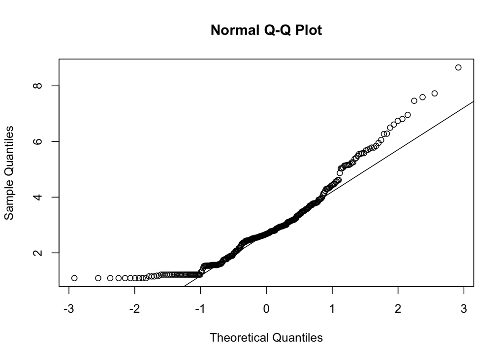

```
##
## =================
##  MISSING DATA IN in A
## #### Little's test for MCAR
##  Little's MCAR Test
##
##     n nIncomp nPattern  chi2 df  pval
##   288       5        6 18.76 47 1.000
##
## #### Amount of missing data
## 0.252525252525253 % of data is missing
##
## Data is NOT MCAR but less than 5% missing data, which is negligible. We are good to continue.
##  Multiple Imputation for missing values in A
##
## =================
##  FACTORABILITY in A
##
##  #### Bartlett in A
## The p value is below 0.05. We are good to continue.
##
## $chisq
## [1] 1898.433
##
## $p.value
## [1] 0
##
## $df
## [1] 55
##
##
##  #### KMO in A
## The overall measure of sampling adequacy is:  0.915229187624931
##
## The sampling adequacy is above 0.7. We are generally good.
##
##
## =================
##  RELIABILITY with 4 factors in A
```

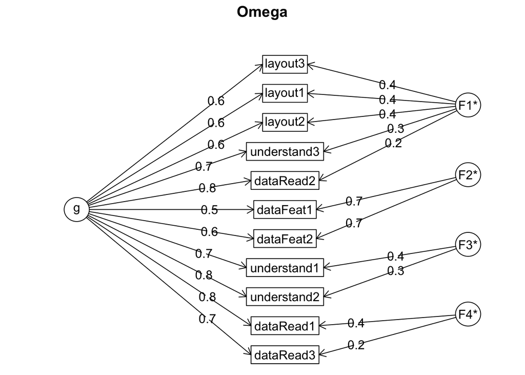

```
## [1] "Alpha: 0.917196653738497"
## [1] "G.6: 0.928700047195411"
## [1] "Omega H asymptotic: 0.824075495540746"
## [1] "Omega Total: 0.94498114987472"
##
## =================
##  NORMALITY in B
##
##  #### Shapiro in B
##
##  #### Multivariate normality in B
```

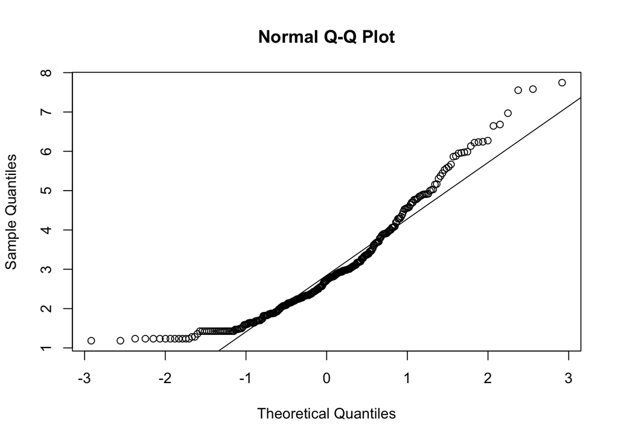

```
##
## =================
##  MISSING DATA IN in B
## #### Little's test for MCAR
##  Little's MCAR Test
##
##     n nIncomp nPattern  chi2 df  pval
##   288       4        4 24.31 27 0.613
##
## #### Amount of missing data
## 0.220959595959596 % of data is missing
##
## Data is NOT MCAR but less than 5% missing data, which is negligible. We are good to continue.
##  Multiple Imputation for missing values in B
##
## =================
##  FACTORABILITY in B
##
##  #### Bartlett in B
## The p value is below 0.05. We are good to continue.
##
## $chisq
## [1] 1774.199
##
## $p.value
## [1] 0
##
## $df
## [1] 55
##
##
##  #### KMO in B
## The overall measure of sampling adequacy is:  0.887817945344406
##
## The sampling adequacy is above 0.7. We are generally good.
##
##
## =================
##  RELIABILITY with 4 factors in B
```

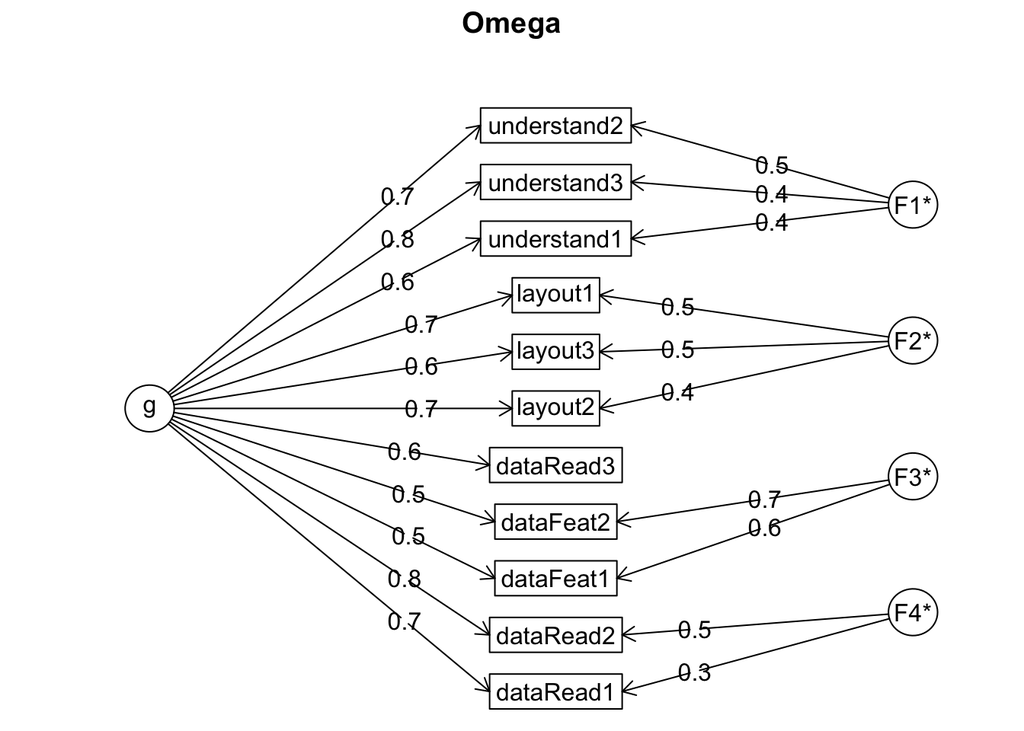

```
## [1] "Alpha: 0.90559744897226"
## [1] "G.6: 0.92224190326131"
## [1] "Omega H asymptotic: 0.82515836702458"
## [1] "Omega Total: 0.940678906192091"
##
## =================
##  NORMALITY in C
##
##  #### Shapiro in C
##
##  #### Multivariate normality in C
```

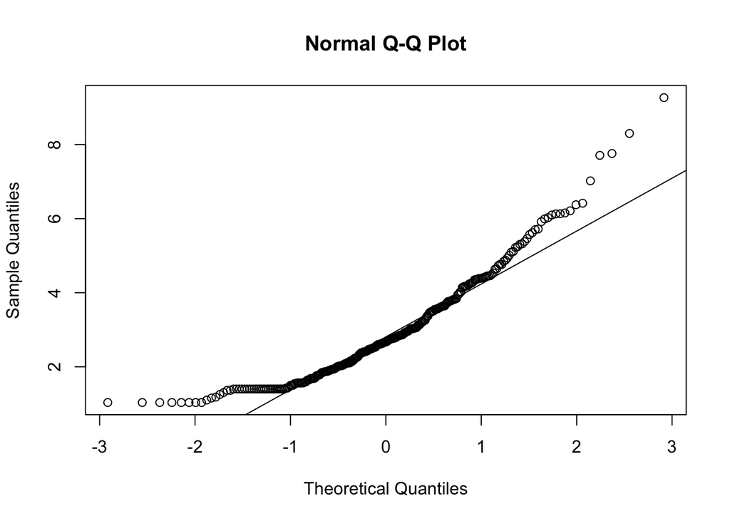

```
##
## =================
##  MISSING DATA IN in C
## #### Little's test for MCAR
##  Little's MCAR Test
##
##     n nIncomp nPattern  chi2 df  pval
##   287       6        7 57.81 59 0.520
##
## #### Amount of missing data
## 0.221729490022173 % of data is missing
##
## Data is NOT MCAR but less than 5% missing data, which is negligible. We are good to continue.
##  Multiple Imputation for missing values in C
##
## =================
##  FACTORABILITY in C
##
##  #### Bartlett in C
## The p value is below 0.05. We are good to continue.
##
## $chisq
## [1] 1709.405
##
## $p.value
## [1] 1.566188e-321
##
## $df
## [1] 55
##
##
##  #### KMO in C
## The overall measure of sampling adequacy is:  0.884749031652285
##
## The sampling adequacy is above 0.7. We are generally good.
##
##
## =================
##  RELIABILITY with 4 factors in C
```

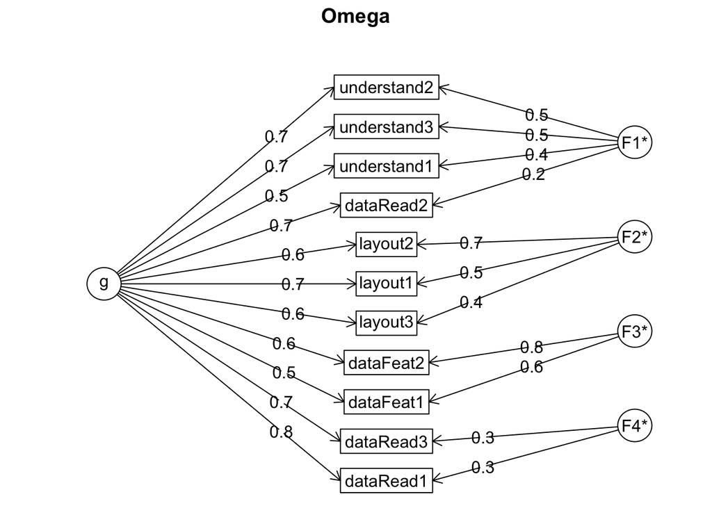

```
## [1] "Alpha: 0.90059503622237"
## [1] "G.6: 0.918731268115187"
## [1] "Omega H asymptotic: 0.807026408947749"
## [1] "Omega Total: 0.938685371151388"
##
## =================
##  NORMALITY in D
##
##  #### Shapiro in D
##
##  #### Multivariate normality in D
```

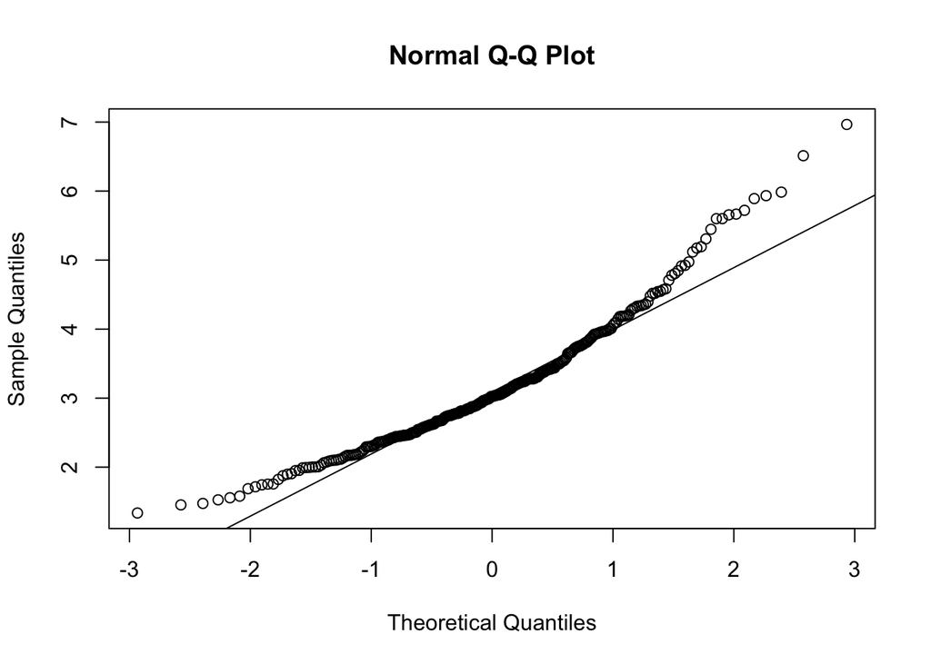

```
##
## =================
##  MISSING DATA IN in D
## #### Little's test for MCAR
##  Little's MCAR Test
##
##     n nIncomp nPattern  chi2 df  pval
##   309      10        7 73.40 59 0.098
##
## #### Amount of missing data
## 0.323624595469256 % of data is missing
##
## Data is NOT MCAR but less than 5% missing data, which is negligible. We are good to continue.
##  Multiple Imputation for missing values in D
##
## =================
##  FACTORABILITY in D
##
##  #### Bartlett in D
## The p value is below 0.05. We are good to continue.
##
## $chisq
## [1] 1851.399
##
## $p.value
## [1] 0
##
## $df
## [1] 55
##
##
##  #### KMO in D
## The overall measure of sampling adequacy is:  0.89384751728325
##
## The sampling adequacy is above 0.7. We are generally good.
##
##
## =================
##  RELIABILITY with 4 factors in D
```

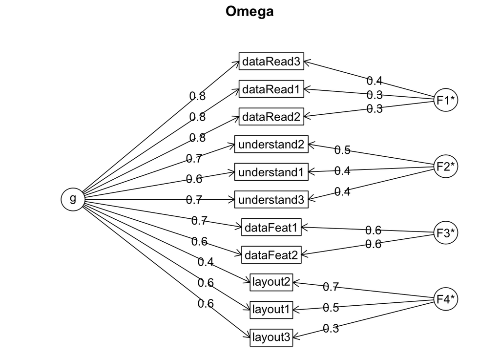

```
## [1] "Alpha: 0.904701177877851"
## [1] "G.6: 0.919634602010228"
## [1] "Omega H asymptotic: 0.827766652636948"
## [1] "Omega Total: 0.940061853092104"
##
## =================
##  NORMALITY in E
##
##  #### Shapiro in E
##
##  #### Multivariate normality in E
```

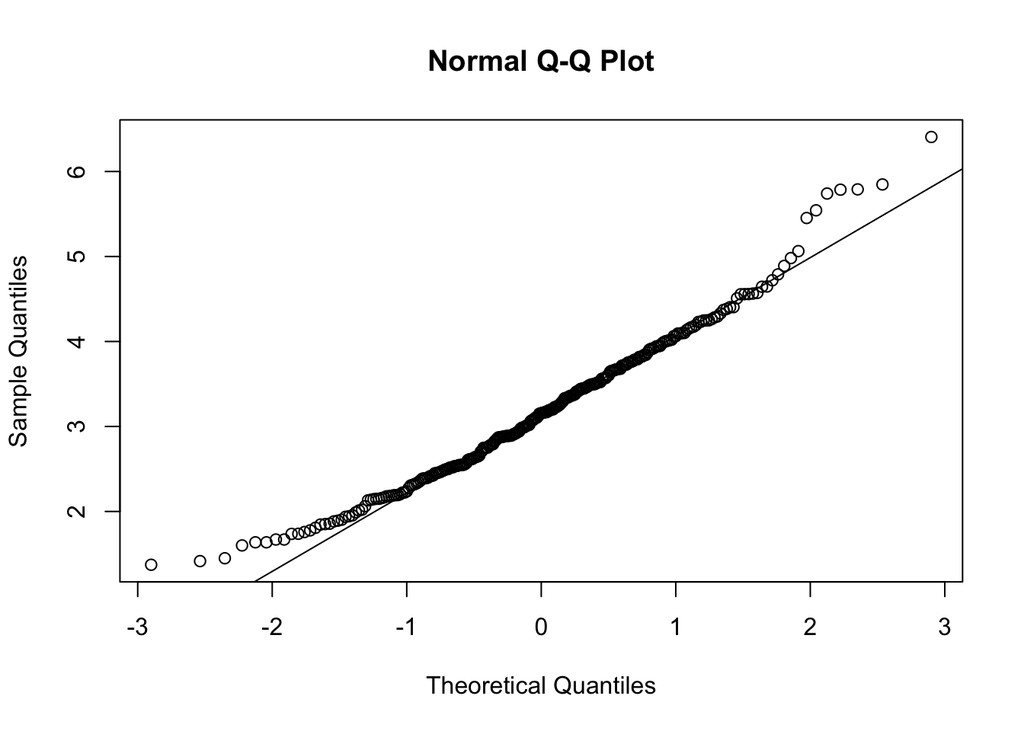

```
##
## =================
##  MISSING DATA IN in E
## #### Little's test for MCAR
##  Little's MCAR Test
##
##     n nIncomp nPattern  chi2 df  pval
##   293      25       10 83.55 85 0.524
##
## #### Amount of missing data
## 1.14799875892026 % of data is missing
##
## Data is NOT MCAR but less than 5% missing data, which is negligible. We are good to continue.
##  Multiple Imputation for missing values in E
##
## =================
##  FACTORABILITY in E
##
##  #### Bartlett in E
## The p value is below 0.05. We are good to continue.
##
## $chisq
## [1] 2101.661
##
## $p.value
## [1] 0
##
## $df
## [1] 55
##
##
##  #### KMO in E
## The overall measure of sampling adequacy is:  0.913936110485708
##
## The sampling adequacy is above 0.7. We are generally good.
##
##
## =================
##  RELIABILITY with 4 factors in E
```

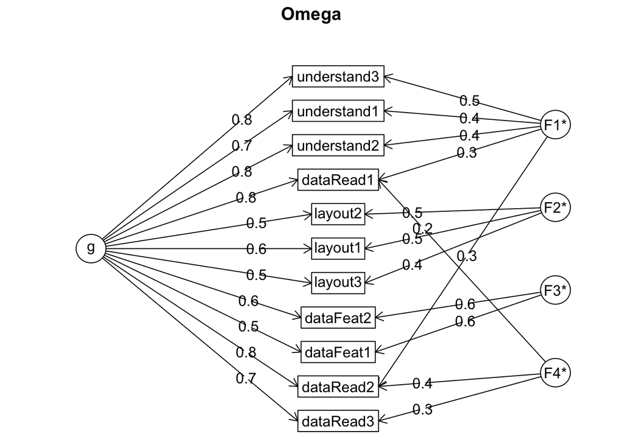

```
## [1] "Alpha: 0.916473035378905"
## [1] "G.6: 0.930337247634491"
## [1] "Omega H asymptotic: 0.805171277602067"
## [1] "Omega Total: 0.946662319158462"
##
## =================
##  NORMALITY in F
##
##  #### Shapiro in F
##
##  #### Multivariate normality in F
```

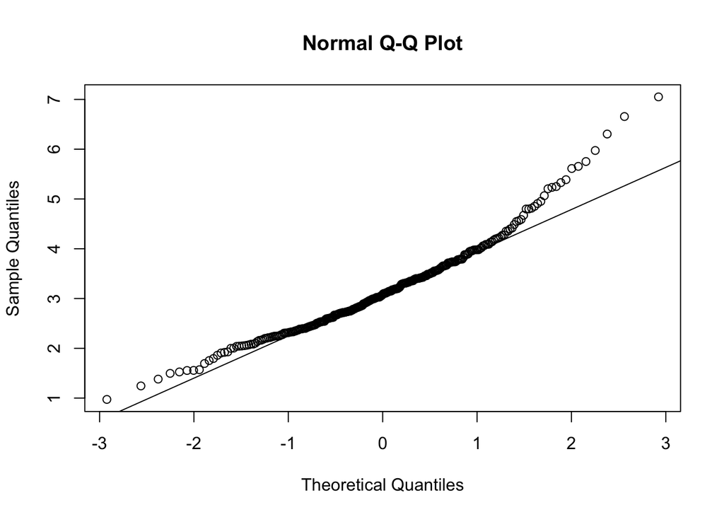

```
##
## =================
##  MISSING DATA IN in F
## #### Little's test for MCAR
##  Little's MCAR Test
##
##     n nIncomp nPattern  chi2 df  pval
##   293       5        6 59.05 49 0.154
##
## #### Amount of missing data
## 0.186161960905988 % of data is missing
##
## Data is NOT MCAR but less than 5% missing data, which is negligible. We are good to continue.
##  Multiple Imputation for missing values in F
##
## =================
##  FACTORABILITY in F
##
##  #### Bartlett in F
## The p value is below 0.05. We are good to continue.
##
## $chisq
## [1] 2085.74
##
## $p.value
## [1] 0
##
## $df
## [1] 55
##
##
##  #### KMO in F
## The overall measure of sampling adequacy is:  0.916804148627633
##
## The sampling adequacy is above 0.7. We are generally good.
##
##
## =================
##  RELIABILITY with 4 factors in F
```

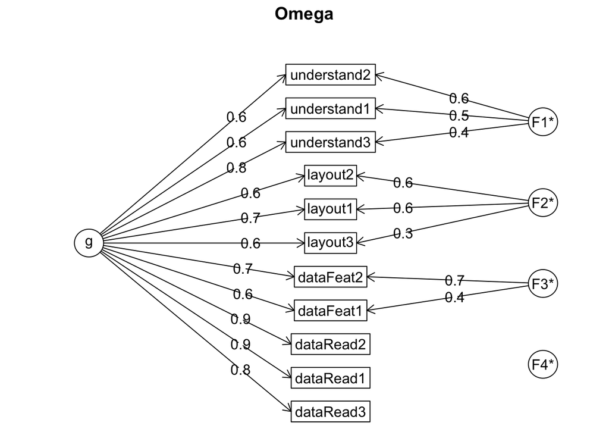

```
## [1] "Alpha: 0.922752989460747"
## [1] "G.6: 0.934581806723019"
## [1] "Omega H asymptotic: 0.860928029474034"
## [1] "Omega Total: 0.952305036586163"
```

```r
cat("\n\n==========================================")
cat("\n==========================================\n")
cat("\n Model fitting for the reduced factors (AFTER item reduction) \n")
```

```
##
##  Model fitting for the reduced factors (AFTER item reduction)
```

```r
cat("==========================================\n")
cat("==========================================\n\n")
cat("\n Model fitting\n")
```

```
##
##  Model fitting
```

```r
  this_fit <- cfa(model_string,
           data = grp_data,
           group = "stimulus",
           missing = "fiml")

# get information per group
summary(this_fit)
```

```
## lavaan 0.6.16 ended normally after 184 iterations
##
##   Estimator                                         ML
##   Optimization method                           NLMINB
##   Number of model parameters                       234
##
##   Number of observations per group:
##     A                                              288
##     B                                              288
##     C                                              287
##     D                                              309
##     E                                              293
##     F                                              293
##   Number of missing patterns per group:
##     A                                                6
##     B                                                4
##     C                                                7
##     D                                                7
##     E                                               10
##     F                                                6
##
## Model Test User Model:
##
##   Test statistic                               477.912
##   Degrees of freedom                               228
##   P-value (Chi-square)                           0.000
##   Test statistic for each group:
##     A                                           84.055
##     B                                           82.628
##     C                                           77.802
##     D                                           93.322
##     E                                           77.489
##     F                                           62.615
##
## Parameter Estimates:
##
##   Standard errors                             Standard
##   Information                                 Observed
##   Observed information based on                Hessian
##
```

[output cut: 398 more lines]

```
##    .obvious           1.130    0.110   10.264    0.000
##    .represent         0.789    0.085    9.288    0.000
##    .understandEasi    0.451    0.077    5.876    0.000
##    .messi             0.368    0.077    4.786    0.000
##    .crowd             0.674    0.073    9.192    0.000
##    .distract          1.712    0.157   10.927    0.000
##    .inform            0.607    0.069    8.793    0.000
##    .identifi          0.541    0.064    8.470    0.000
##    .find              0.779    0.081    9.669    0.000
##    .visibl            0.866    0.107    8.099    0.000
##    .see               0.572    0.122    4.673    0.000
##     understand        1.153    0.174    6.626    0.000
##     layout            1.733    0.185    9.371    0.000
##     dataRead          2.052    0.219    9.366    0.000
##     dataFeat          1.420    0.192    7.397    0.000
```

### Model fit indices

```r
#summary(fit, standardized=TRUE, fit.measures=TRUE)

cat("\n==============\n")
cat("Reduced model fit indices")
```

```
## Reduced model fit indices
```

```r
cat("\n==============\n")
print(fitMeasures(this_fit, c("chisq", "df", "pvalue", "cfi", "rmsea"),
                  output = "text"), add.h0 = TRUE)
```

```
##
## Model Test User Model:
##
##   Test statistic                               477.912
##   Degrees of freedom                               228
##   P-value                                        0.000
##
## User Model versus Baseline Model:
##
##   Comparative Fit Index (CFI)                    0.978
##
## Root Mean Square Error of Approximation:
##
##   RMSEA                                          0.061
```

```r
fit_Indices <- fitMeasures(this_fit, output = "matrix")
colnames(fit_Indices)[1] <- c(this_model)
write.csv(fit_Indices,file=(paste("generatedData-CFA/fit_indices-", this_model, ".csv", sep="")))

# fit_Indices <- fitMeasures(this_fit, c("rmsea","rmsea.pvalue","rmsea.ci.lower","rmsea.ci.upper","rmsea.ci.level","srmr","cfi","chisq","df","pvalue"))
#
# knitr::kable(fit_Indices,
#              caption = "Reduced model fit indices")
```

#### RMSEA (Root Mean Square Error of Approximation): our main indice

RMSEA is a measure of how well the model’s implied relationships between variables match the observed relationships in the data. It measures the average magnitude of the differences between predicted and observed values. In the context of CFA, it looks at how well the model-predicted covariances or correlations match the actual observed covariances or correlations among the variables.

RMSEA values less than 0.05 are good, values between 0.05 and 0.08 are acceptable, values between 0.08 and 0.1 are marginal, and values greater than 0.1 are poor. https://psycnet.apa.org/doi/10.1037/1082-989X.4.3.272

```r
cat("\n RMSEA - \n")

this_RMSEAIndices <- fit_Indices[c("rmsea","rmsea.pvalue","rmsea.ci.lower","rmsea.ci.upper","rmsea.ci.level")]
print(this_RMSEAIndices)
```

[output not shown]

#### SRMR (Standardized Root Mean Square Residual)

SRMR is particularly useful for evaluating the discrepancy between the observed and predicted covariance matrices.

SRMR is computed by taking the square root of the mean squared differences between corresponding elements in these two matrices.

The SRMR is then standardized to be independent of the scale of the observed variables. This makes it more comparable across different datasets and models.

A value less than . 08 is generally considered a good fit (Hu & Bentler, 1999)

```r
cat("\n SRMR \n")
this_SRMRIndices <- fit_Indices[c("srmr")]
print(this_SRMRIndices)
```

[output not shown]

#### CFI (Comparative Fit Index)

CFI is calculated by comparing the fit of the hypothesized model to a null model that assumes complete independence among the observed variables. The index ranges from 0 to 1, with higher values indicating better fit. A common rule of thumb is that CFI values above 0.90 or 0.95 are indicative of an acceptable or good fit, respectively.

```r
cat("\n Comparative Fit Index \n")
this_CFIIndices <- fit_Indices[c("cfi")]
print(this_CFIIndices)
```

[output not shown]

#### Chi-square

It is calculated by comparing the observed sample covariance matrix with the covariance matrix predicted by the specified model. The formula involves summing the squared differences between the observed and expected (model-implied) covariances, adjusted for the sample size.

The chi-square test requires specifying the degrees of freedom, which depend on the complexity of the model. A small chi-square value relative to its degrees of freedom suggests that the model fits the data well. Conversely, a large chi-square value may indicate a poor fit between the model and the data.

1. Significance Test: The chi-square statistic is associated with a p-value (pvalue) that tests the null hypothesis. If the p-value is small (typically below a chosen significance level, such as 0.05), it suggests that there is evidence to reject the null hypothesis, indicating that the model does not fit the data well. In your provided data, the p-value associated with chisq is 0.000, suggesting that the model significantly deviates from the observed data.
2. Model Complexity: The chi-square statistic is sensitive to model complexity, meaning that as the model becomes more complex (e.g., with more estimated parameters), the chi-square tends to increase. Therefore, larger chi-square values may be expected for more complex models.
3. Sample Size Influence: The chi-square test can be influenced by sample size. In large samples, even small discrepancies between the model and the data can lead to a significant chi-square. Researchers often consider this and use additional fit indices, such as the Comparative Fit Index (CFI), Root Mean Square Error of Approximation (RMSEA), and Standardized Root Mean Square Residual (SRMR), to assess model fit.

```r
cat("\n Chi-square \n")
this_ChiSquareIndices <- fit_Indices[c("chisq","df","pvalue")]
print(this_ChiSquareIndices)
```

[output not shown]

### Measurement invariance testing

https://lavaan.ugent.be/tutorial/groups.html#measurement-invariance-testing NB: Intercepts represent the average score or level of the latent construct when all other variables (including other latent constructs and observed variables) are held constant.

Pr(>Chisq) tells us if the less constrained model fits the data significantly better (e.g., that fit1 fits the data better compared to fit2)

fit1 = basic model, per group analysis fit2 = model with constraint on factor loadings (equal loadings among groups) fit3 = model with constraint on both loadings and intercepts

```r
cat("\n Measurement invariance\n")
```

```
##
##  Measurement invariance
```

```r
# configural invariance
fit1 <- this_fit

# weak invariance
fit2 <- cfa(model_string, data = grp_data, missing = "fiml", group = "stimulus",
            group.equal = "loadings")

# strong invariance
fit3 <- cfa(model_string, data = grp_data, missing = "fiml", group = "stimulus",
            group.equal = c("intercepts", "loadings"))

# model comparison tests
lavTestLRT(fit1, fit2, fit3)
```

```
##
## Chi-Squared Difference Test
##
##       Df   AIC   BIC   Chisq Chisq diff    RMSEA Df diff Pr(>Chisq)
## fit1 228 54342 55622  477.91
## fit2 263 54362 55451  568.71      90.80 0.073767      35  7.583e-07 ***
## fit3 298 54758 55656 1034.72     466.01 0.205010      35  < 2.2e-16 ***
## ---
## Signif. codes:  0 '***' 0.001 '**' 0.01 '*' 0.05 '.' 0.1 ' ' 1
```

```r
# build a model for a latent trait and 4 factors

# Create a string for the overall readability factor
overall_readability <- paste(unlist(Readability_factors), collapse = " + ")

# Create strings for each individual factor
factor_strings <- lapply(names(Readability_factors), function(factor_name) {
  paste(factor_name, " =~ ", paste(unlist(Readability_factors[[factor_name]]), collapse = " + "))
})

# Combine overall and individual factor strings
global_model_string <- c("readability =~ ", overall_readability, factor_strings)
global_model_string <- paste(global_model_string, collapse = "\n")
print(global_model_string)

global_fit <- cfa(global_model_string, data = grp_data, missing = "fiml", group = "stimulus")

omegaFromSem(global_fit,m=corrFiml,flip=TRUE,plot=TRUE)
# library(sem) # for omega
# omegaFromSem(global_fit,plot=TRUE)
```

[output not shown]